# Correlated dependencies with VPS4A dependency

Guillaume Kugener

2019-06-12

## Objective

```r
plot_saving_directory <- '~/Documents/gkugener/VPS4A/plots/associated_deps_with_vps4a/'
dir.create(plot_saving_directory)
```

In this anlaysis we are interested in looking at dependencies that may be associated with VPS4A/B features.

```r
gene.effect.corrected <- load.from.taiga(data.name='avana-public-tentative-19q2-2025', data.version=1, data.file='gene_effect')
public.CCLE.expression <- load.from.taiga(data.name='public-19q2-5572', data.version=10, data.file='CCLE_expression')
public.CCLE.gene.cn <- load.from.taiga(data.name='public-19q2-5572', data.version=10, data.file='CCLE_gene_cn')
```

### VPS4 combined expression

We create a feature here where we calculate a combined VPS4 expression (log2(VPS4A TPM + VPS4B TPM)). We correlated this expression feature with dependencies in the Avana dataset (above).

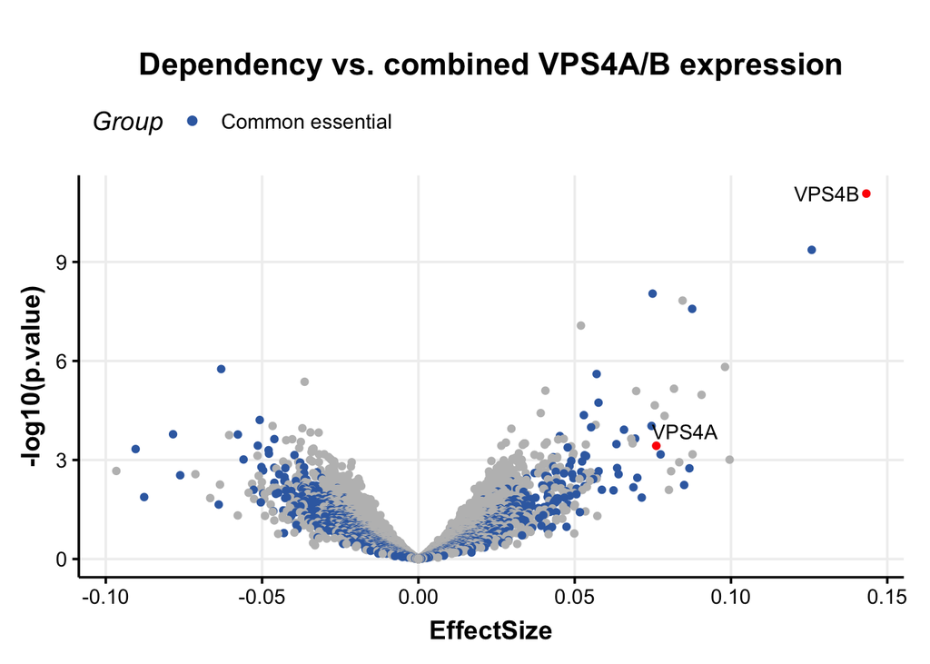

The table below highlights the top 200 correlated genes (positive or negative) by p.value

|  | Gene | Group | EffectSize | Avg | t_stat | p.value | q.value | log_odds | min_samples | p.left | p.right | q.left | q.right |
| --- | --- | --- | --- | --- | --- | --- | --- | --- | --- | --- | --- | --- | --- |
| 1 | VPS4B (9525) |  | 0.143 | -0.149 | 6.962 | 0 | 0 | 16.206 | 620 | 1 | 0 | 1 | 0 |
| 2 | WDR7 (23335) | Common essential | 0.126 | -0.912 | 6.343 | 0 | 0 | 12.391 | 620 | 1 | 0 | 1 | 0 |
| 3 | CENPT (80152) | Common essential | 0.075 | -0.675 | 5.825 | 0 | 0 | 9.439 | 620 | 1 | 0 | 1 | 0 |
| 4 | HTT (3064) |  | 0.085 | -0.1 | 5.739 | 0 | 0 | 8.971 | 620 | 1 | 0 | 1 | 0 |
| 5 | ZNF407 (55628) | Common essential | 0.088 | -0.616 | 5.635 | 0 | 0 | 8.413 | 620 | 1 | 0 | 1 | 0 |
| 6 | KRTAP4-11 (653240) |  | 0.052 | -0.091 | 5.421 | 0 | 0 | 7.291 | 620 | 1 | 0 | 1 | 0 |
| 7 | PAX8 (7849) |  | 0.098 | -0.07 | 4.856 | 0 | 0.004 | 4.524 | 620 | 1 | 0 | 1 | 0.002 |
| 8 | MED8 (112950) | Common essential | -0.063 | -1.098 | -4.825 | 0 | 0.004 | 4.385 | 620 | 0 | 1 | 0.015 | 1 |
| 9 | CFDP1 (10428) | Common essential | 0.057 | -0.573 | 4.754 | 0 | 0.005 | 4.055 | 620 | 1 | 0 | 1 | 0.003 |
| 10 | SENP7 (57337) |  | -0.036 | -0.022 | -4.639 | 0 | 0.008 | 3.538 | 620 | 0 | 1 | 0.019 | 1 |

[output cut: 190 more lines]

### VPS4 combined copy number

We create a feature here where we calculate a combined VPS4 copy number (log2(VPS4A CN + VPS4B CN + 1)). We correlated this copy number feature with dependencies in the Avana dataset (above).

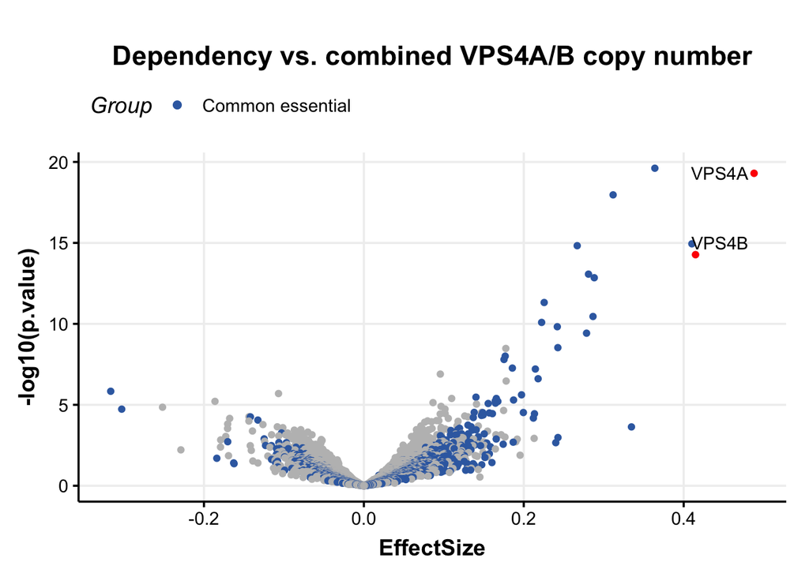

The table below highlights the top 200 correlated genes (positive or negative) by p.value

|  | Gene | Group | EffectSize | Avg | t_stat | p.value | q.value | log_odds | min_samples | p.left | p.right | q.left | q.right |
| --- | --- | --- | --- | --- | --- | --- | --- | --- | --- | --- | --- | --- | --- |
| 1 | ZNF407 (55628) | Common essential | 0.364 | -0.616 | 9.562 | 0 | 0 | 34.323 | 632 | 1 | 0 | 1 | 0 |
| 2 | VPS4A (27183) |  | 0.488 | -0.318 | 9.476 | 0 | 0 | 33.649 | 632 | 1 | 0 | 1 | 0 |
| 3 | NARS (4677) | Common essential | 0.312 | -1.223 | 9.106 | 0 | 0 | 30.793 | 632 | 1 | 0 | 1 | 0 |
| 4 | WDR7 (23335) | Common essential | 0.41 | -0.916 | 8.219 | 0 | 0 | 24.314 | 632 | 1 | 0 | 1 | 0 |
| 5 | CENPT (80152) | Common essential | 0.267 | -0.677 | 8.184 | 0 | 0 | 24.064 | 632 | 1 | 0 | 1 | 0 |
| 6 | VPS4B (9525) |  | 0.415 | -0.149 | 8.013 | 0 | 0 | 22.879 | 632 | 1 | 0 | 1 | 0 |
| 7 | ZNF236 (7776) | Common essential | 0.281 | -0.445 | 7.631 | 0 | 0 | 20.304 | 632 | 1 | 0 | 1 | 0 |
| 8 | SKA1 (220134) | Common essential | 0.288 | -0.488 | 7.558 | 0 | 0 | 19.83 | 632 | 1 | 0 | 1 | 0 |
| 9 | TANGO6 (79613) | Common essential | 0.226 | -1.027 | 7.045 | 0 | 0 | 16.562 | 632 | 1 | 0 | 1 | 0 |
| 10 | PIK3C3 (5289) | Common essential | 0.287 | -0.785 | 6.741 | 0 | 0 | 14.72 | 632 | 1 | 0 | 1 | 0 |

[output cut: 190 more lines]

### VPS4A dependency

Here, we look for dependencies that are correlated with VPS4A dependency. A positive effect coefficient indicates positive correlation with the dependency.

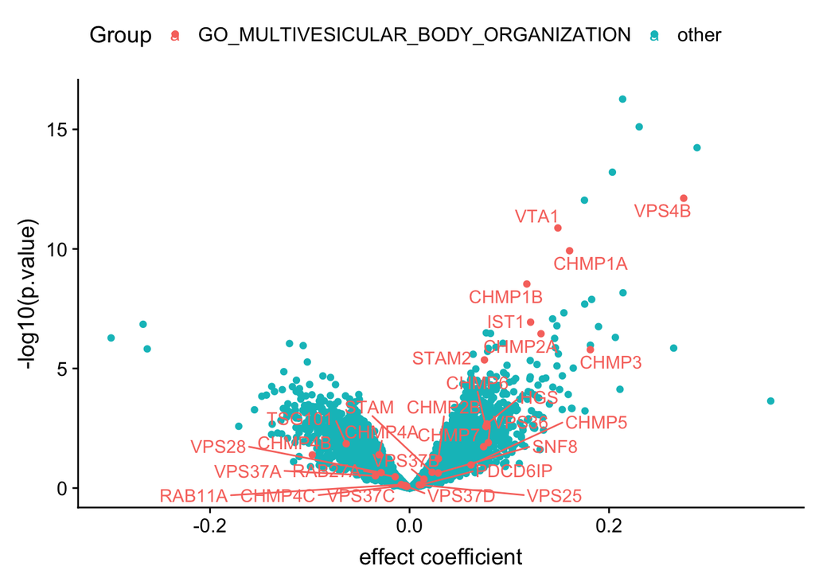

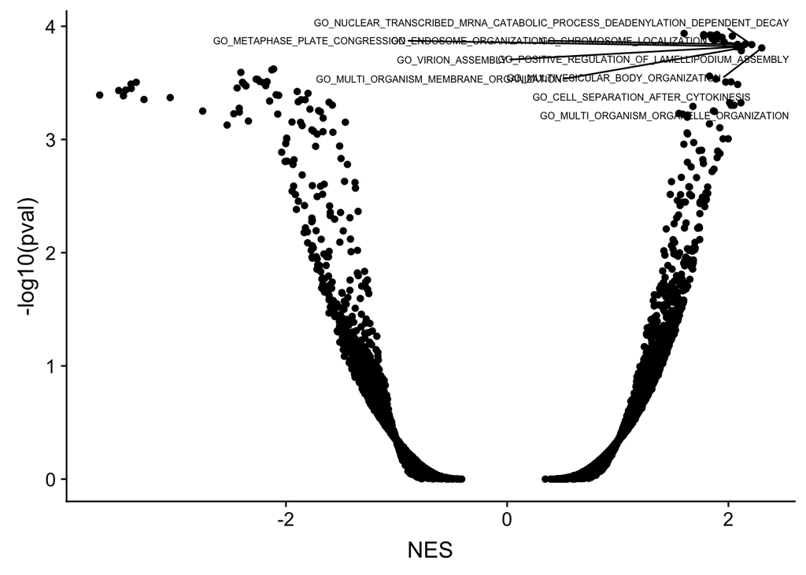

|  | pathway | pval | padj | ES | NES | nMoreExtreme | size | leadingEdge |
| --- | --- | --- | --- | --- | --- | --- | --- | --- |
| 1 | GO_MULTIVESICULAR_BODY_ORGANIZATION | 0.000155376009944065 | 0.0286951240183061 | 0.708554927593923 | 2.30125265268813 | 0 | 29 | ['VPS4B', 'VTA1', 'CHMP1A', 'CHMP1B', 'IST1', 'CHMP2A', 'CHMP3', 'STAM2', 'HGS', 'CHMP6', 'VPS36', 'CHMP7'] |
| 2 | GO_NUCLEAR_TRANSCRIBED_MRNA_CATABOLIC_PROCESS_DEADENYLATION_DEPENDENT_DECAY | 0.000145180023228804 | 0.0286951240183061 | 0.596420005826668 | 2.21112562369304 | 0 | 54 | ['EDC4', 'LSM5', 'CNOT6', 'RQCD1', 'EXOSC5', 'CNOT1', 'LSM6', 'CNOT7', 'PABPC1', 'CNOT10', 'LSM7', 'ZFP36L1', 'LSM3', 'EIF4E', 'EIF4B', 'LSM4', 'LSM2', 'DCPS', 'EXOSC7', 'CNOT8', 'EIF4A1', 'CNOT4', 'C… |
| 3 | GO_CHROMOSOME_LOCALIZATION | 0.000144571345959231 | 0.0286951240183061 | 0.573126881602708 | 2.14893969309523 | 0 | 58 | ['VPS4B', 'CHMP1A', 'CHMP1B', 'CHMP2A', 'CHMP3', 'ACTR3', 'KIF18A', 'KATNB1', 'ATM', 'NDE1', 'KIFC1', 'CHMP6', 'ACTR2', 'KIF14', 'CDCA5', 'CHMP7', 'CCNB1', 'SEH1L', 'KIF22', 'CHMP2B'] |
| 4 | GO_POSITIVE_REGULATION_OF_LAMELLIPODIUM_ASSEMBLY | 0.000164284540824708 | 0.0290212212769909 | 0.762704737608118 | 2.11669640224315 | 0 | 15 | ['RAC1', 'ARPC2', 'WASF2', 'NCKAP1', 'BRK1'] |
| 5 | GO_MULTI_ORGANISM_MEMBRANE_ORGANIZATION | 0.000155376009944065 | 0.0286951240183061 | 0.651696303315054 | 2.1165865740903 | 0 | 29 | ['VPS4B', 'VTA1', 'CHMP1A', 'CHMP1B', 'CHMP2A', 'CHMP3', 'CHMP6', 'CHMP7', 'GAS6', 'CHMP2B'] |
| 6 | GO_MULTI_ORGANISM_ORGANELLE_ORGANIZATION | 0.000474458326743634 | 0.0315474314039422 | 0.694183856124876 | 2.11293293276799 | 2 | 22 | ['VPS4B', 'VTA1', 'CHMP1A', 'CHMP1B', 'CHMP2A', 'CHMP3', 'CHMP6', 'CHMP7'] |
| 7 | GO_VIRION_ASSEMBLY | 0.000151653017895056 | 0.0286951240183061 | 0.619618647627814 | 2.1023371018542 | 0 | 35 | ['VPS4B', 'VTA1', 'CHMP1A', 'CHMP1B', 'CHMP2A', 'CHMP3', 'CHMP6', 'UBB', 'CHMP7', 'TBC1D20'] |
| 8 | GO_METAPHASE_PLATE_CONGRESSION | 0.000150398556173861 | 0.0286951240183061 | 0.600635745769765 | 2.09384134318651 | 0 | 40 | ['VPS4B', 'CHMP1A', 'CHMP1B', 'CHMP2A', 'CHMP3', 'KIF18A', 'KIFC1', 'CHMP6', 'KIF14', 'CDCA5', 'CHMP7', 'CCNB1', 'SEH1L', 'KIF22', 'CHMP2B', 'KIF2C', 'CHMP5'] |
| 9 | GO_CELL_SEPARATION_AFTER_CYTOKINESIS | 0.000326477309826967 | 0.0315474314039422 | 0.738783890443282 | 2.08351280856031 | 1 | 16 | ['VPS4B', 'CHMP1A', 'CHMP1B', 'CHMP2A', 'CHMP3', 'CHMP6', 'CHMP7', 'CHMP2B', 'KIF20A', 'CHMP5'] |
| 10 | GO_ENDOSOME_ORGANIZATION | 0.000144571345959231 | 0.0286951240183061 | 0.555404025259805 | 2.08248782930587 | 0 | 58 | ['VPS4B', 'VTA1', 'CHMP1A', 'CHMP1B', 'PIK3C3', 'IST1', 'CHMP2A', 'CHMP3', 'STAM2', 'HGS', 'CHMP6', 'VPS36', 'DNAJC13', 'CHMP7', 'TMEM127', 'CHMP2B', 'ARFGEF2'] |

[output cut: 90 more lines]

## Associated features with VPS4B loss

From Paquita’s observation: It seems clear that VPS4B loss is necessary but not sufficient to explain VPS4A dependency. Can we do an analysis only with cell lines with VPS4B loss to see if anything comes up?

In these analyses, we are interested in finding features that are associated with VPS4A dependency in lines that are VPS4B lost.

### Defiining VPS4B loss

We will use a relative log2(CN) cutoff of -0.5 to indicate loss of VPS4B

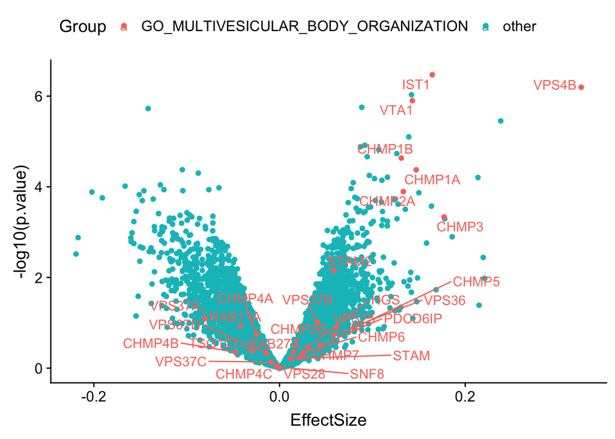

|  | pathway | pval | padj | ES | NES | nMoreExtreme | size | leadingEdge |
| --- | --- | --- | --- | --- | --- | --- | --- | --- |
| 1 | GO_MULTIVESICULAR_BODY_ORGANIZATION | 0.000369139904023625 | 0.0339113197704747 | 0.632890337823263 | 2.14880140733899 | 1 | 29 | ['IST1', 'VPS4B', 'VTA1', 'CHMP1B', 'CHMP1A', 'CHMP2A', 'CHMP3', 'STAM2', 'VPS37B', 'VPS25', 'CHMP5', 'VPS36'] |
| 2 | GO_MULTI_ORGANISM_MEMBRANE_ORGANIZATION | 0.000369139904023625 | 0.0339113197704747 | 0.632673507973636 | 2.14806522247696 | 1 | 29 | ['VPS4B', 'VTA1', 'CHMP1B', 'CHMP1A', 'CHMP2A', 'CHMP3', 'GAS6', 'CD4', 'VPS37B', 'CHMP5'] |
| 3 | GO_NUCLEOTIDE_EXCISION_REPAIR_DNA_GAP_FILLING | 0.000184229918938836 | 0.0304367368342198 | 0.660311856842661 | 2.13676184544462 | 0 | 24 | ['RFC5', 'RFC1', 'LIG1', 'XRCC1', 'RFC2', 'LIG4', 'POLD1', 'RFC4', 'UBC', 'RPA3', 'POLE', 'POLD2', 'POLD3', 'POLK', 'RFC3', 'POLB', 'UBB', 'RPA1'] |
| 4 | GO_DNA_REPLICATION_INITIATION | 0.000184229918938836 | 0.0304367368342198 | 0.640131660286626 | 2.1140882727595 | 0 | 26 | ['ORC4', 'ORC2', 'ORC1', 'GINS2', 'LRWD1', 'MCM2', 'CDC34', 'GMNC', 'PRIM1', 'POLA2', 'MCM4', 'POLE', 'MCM5', 'MCM6', 'CCNE2', 'CDC7', 'CDC45'] |
| 5 | GO_MULTI_ORGANISM_ORGANELLE_ORGANIZATION | 0.000369617445943449 | 0.0339113197704747 | 0.662564979480475 | 2.10074278356731 | 1 | 22 | ['VPS4B', 'VTA1', 'CHMP1B', 'CHMP1A', 'CHMP2A', 'CHMP3', 'VPS37B', 'CHMP5'] |
| 6 | GO_ATTACHMENT_OF_SPINDLE_MICROTUBULES_TO_KINETOCHORE | 0.000375586854460094 | 0.0339113197704747 | 0.73928720672527 | 2.07434011659134 | 1 | 14 | ['FAM175B', 'NDC80', 'RB1', 'AURKB', 'CASC5'] |
| 7 | GO_NADP_METABOLIC_PROCESS | 0.00018450184501845 | 0.0304367368342198 | 0.627313643821619 | 2.05191398005154 | 0 | 25 | ['PGD', 'RPE', 'KCNAB2', 'TKT', 'CYB5R4', 'TP53I3', 'RPIA', 'FMO2', 'ASPDH', 'SHPK', 'PGLS', 'FMO1'] |
| 8 | GO_CELL_SEPARATION_AFTER_CYTOKINESIS | 0.00037202380952381 | 0.0339113197704747 | 0.697909624463471 | 2.02808641267301 | 1 | 16 | ['VPS4B', 'CHMP1B', 'CHMP1A', 'CHMP2A', 'CHMP3', 'KIF20A', 'CHMP5'] |
| 9 | GO_PYRIMIDINE_CONTAINING_COMPOUND_BIOSYNTHETIC_PROCESS | 0.000184094256259205 | 0.0304367368342198 | 0.567373419400376 | 2.01247225788206 | 0 | 35 | ['TK2', 'ERH', 'TBPL1', 'TYMS', 'TK1', 'DHFRL1', 'DTYMK', 'NME5', 'DCTD', 'DUT', 'NME2', 'NME7', 'CMPK2', 'DHODH', 'UCK2', 'NME1', 'TPK1', 'UCK1'] |
| 10 | GO_RNA_SPLICING_VIA_TRANSESTERIFICATION_REACTIONS | 0.000162972620599739 | 0.0304367368342198 | 0.406181341473422 | 2.01128643454588 | 0 | 242 | ['SF3B3', 'LUC7L2', 'GPATCH1', 'LSM5', 'CELF4', 'DDX23', 'NUDT21', 'CD2BP2', 'RNPS1', 'PRPF19', 'CLNS1A', 'POLR2F', 'SNRPG', 'SF3B4', 'TFIP11', 'SRRM2', 'PPWD1', 'PDCD7', 'CWC27', 'SNW1', 'POLR2E', 'M… |

[output cut: 90 more lines]

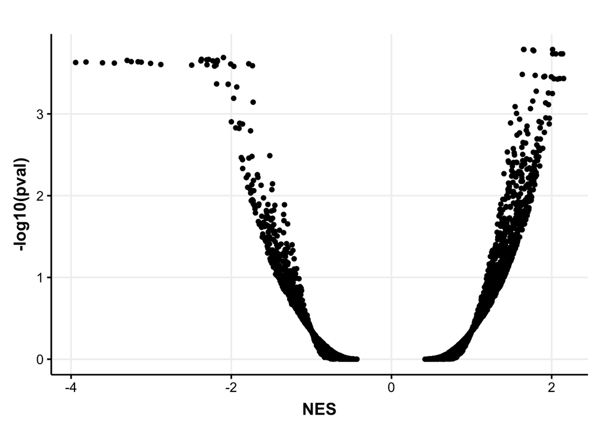